# linreg2

## Linear Regression: Part 2

We are working with a dataset from a fictional health insurance company. The data is contained in a CSV file (already uploaded in the Files pane at right). Let’s load the data and take a look at what we have.

```r
insurance = read_csv("insurance.csv")
```

Examine the dataset

```r
str(insurance)
```

```
spc_tbl_ [1,338 × 7] (S3: spec_tbl_df/tbl_df/tbl/data.frame)
 $ age     : num [1:1338] 19 18 28 33 32 31 46 37 37 60 ...
 $ sex     : chr [1:1338] "female" "male" "male" "male" ...
 $ bmi     : num [1:1338] 27.9 33.8 33 22.7 28.9 ...
 $ children: num [1:1338] 0 1 3 0 0 0 1 3 2 0 ...
 $ smoker  : chr [1:1338] "yes" "no" "no" "no" ...
 $ region  : chr [1:1338] "southwest" "southeast" "southeast" "northwest" ...
 $ charges : num [1:1338] 16885 1726 4449 21984 3867 ...
 - attr(*, "spec")=
  .. cols(
  ..   age = col_double(),
  ..   sex = col_character(),
  ..   bmi = col_double(),
  ..   children = col_double(),
  ..   smoker = col_character(),
  ..   region = col_character(),
  ..   charges = col_double()
  .. )
 - attr(*, "problems")=<externalptr>
```

Some factor conversions are necessary as we have categorical variables:

Level = categorical variable *(smoker is an example)*

```r
insurance = insurance %>% mutate(sex = as_factor(sex)) %>%
  mutate(smoker = as_factor(smoker)) %>%
  mutate(region = as_factor(region))

summary(insurance)
```

```
      age            sex           bmi           children     smoker
 Min.   :18.00   female:662   Min.   :15.96   Min.   :0.000   yes: 274
 1st Qu.:27.00   male  :676   1st Qu.:26.30   1st Qu.:0.000   no :1064
 Median :39.00                Median :30.40   Median :1.000
 Mean   :39.21                Mean   :30.66   Mean   :1.095
 3rd Qu.:51.00                3rd Qu.:34.69   3rd Qu.:2.000
 Max.   :64.00                Max.   :53.13   Max.   :5.000
       region       charges
 southwest:325   Min.   : 1122
 southeast:364   1st Qu.: 4740
 northwest:325   Median : 9382
 northeast:324   Mean   :13270
                 3rd Qu.:16640
                 Max.   :63770
```

No missing data. Move on to visualization. Let’s start with our numeric variables.

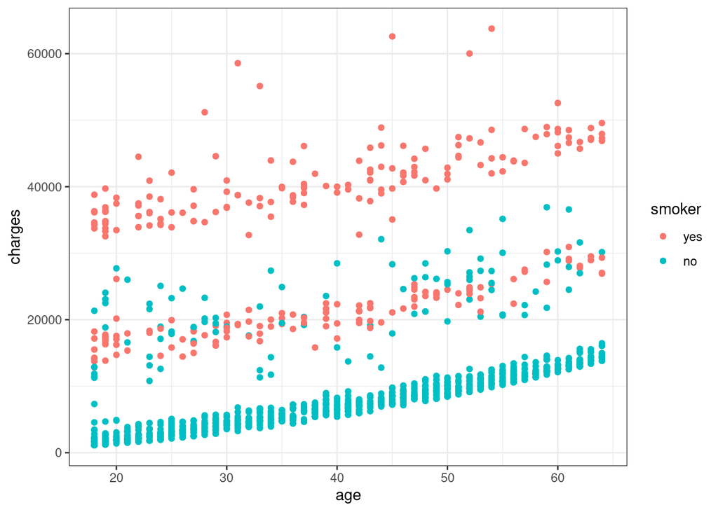

```r
ggplot(insurance, aes(x=age,y=charges,color=smoker)) + geom_point() + theme_bw()
```

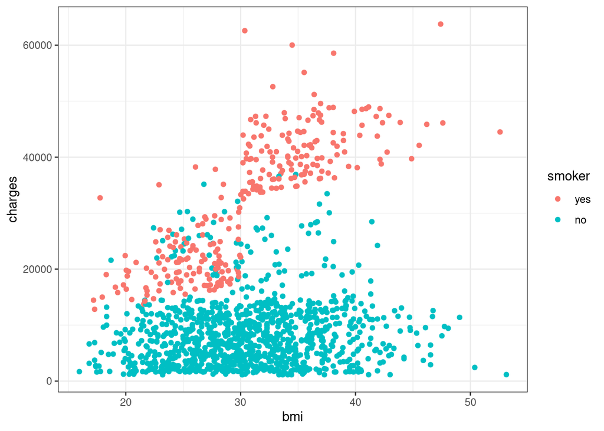

```r
ggplot(insurance, aes(x=bmi,y=charges,color=smoker)) + geom_point() + theme_bw()
```

children is temporarily changed to factor for this plot

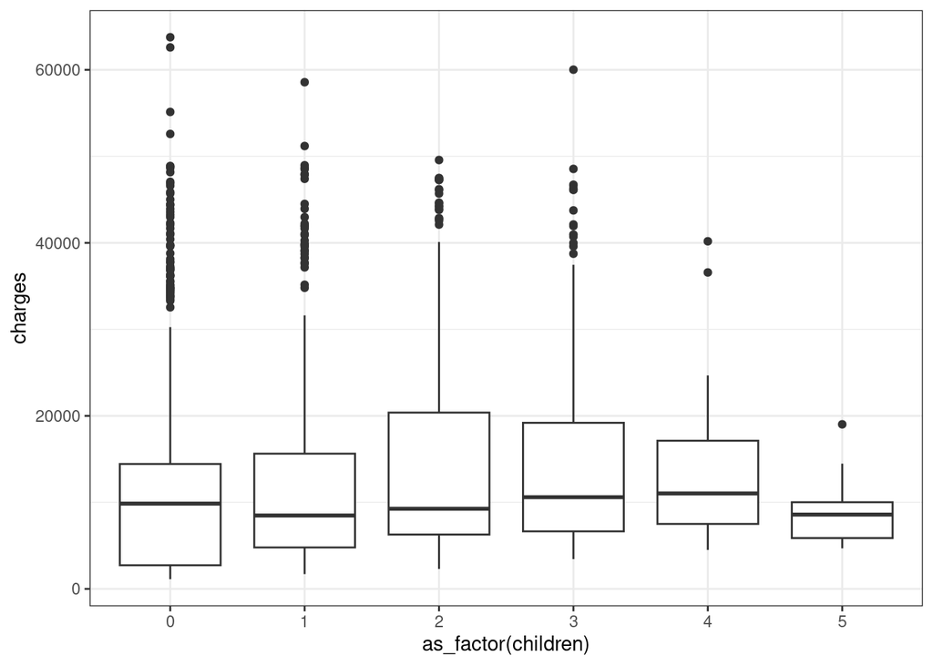

```r
ggplot(insurance, aes(x=as_factor(children),y=charges)) + geom_boxplot() + theme_bw()
```

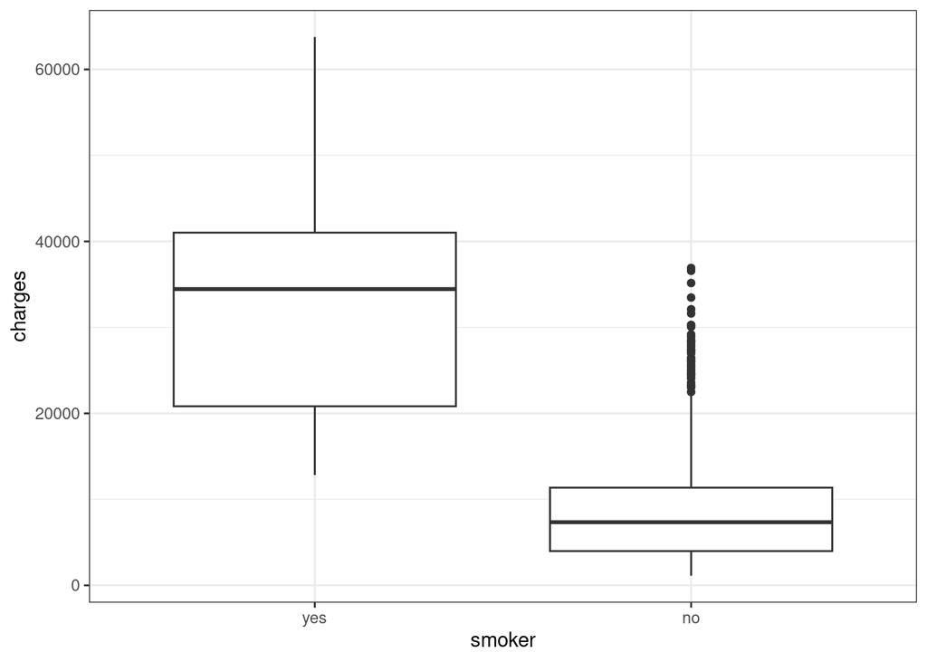

```r
ggplot(insurance, aes(x=smoker,y=charges)) + geom_boxplot() + theme_bw()
```

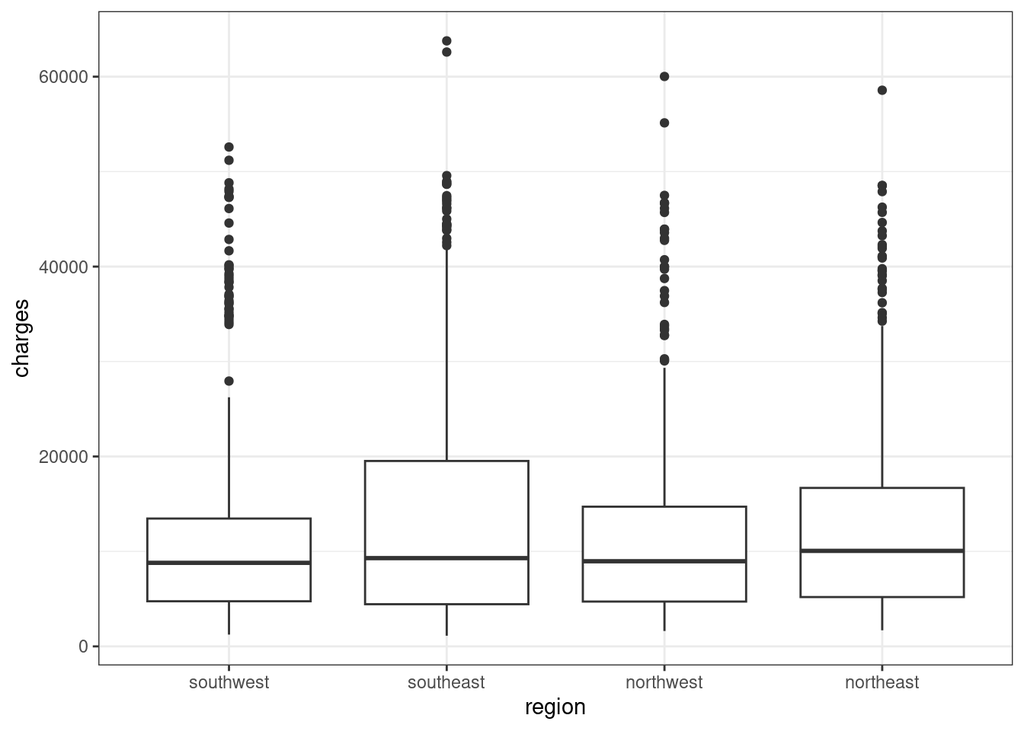

```r
ggplot(insurance, aes(x=region,y=charges)) + geom_boxplot() + theme_bw()
```

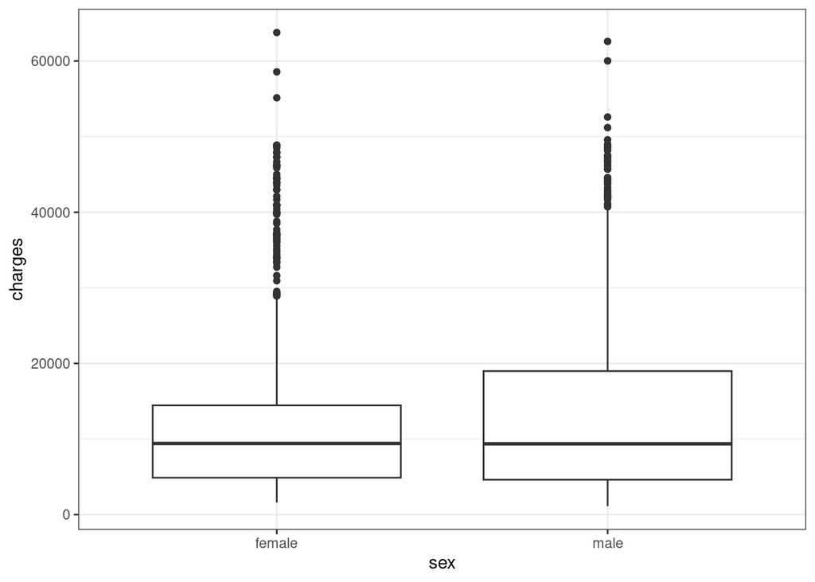

```r
ggplot(insurance, aes(x=sex,y=charges)) + geom_boxplot() + theme_bw()
```

Next in our workflow, we look at correlation of the numeric predictors (or potential predictors) with the response. NOTE: Because we have categorical variables, we need to exclude them from the correlation matrix creation!

What does this plot tell us?

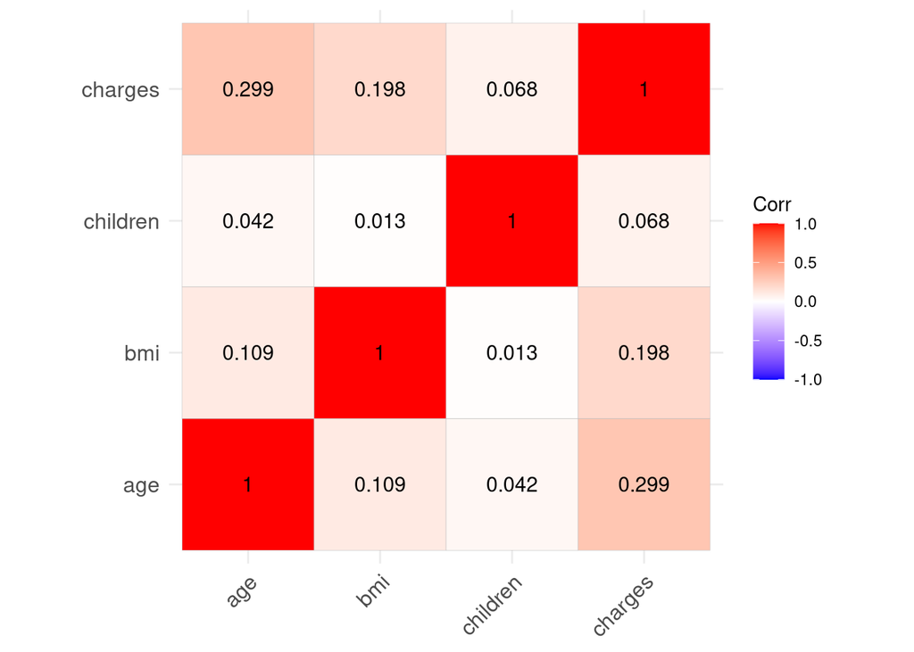

```r
corr = insurance %>% select(-sex, -smoker, -region) %>% cor(.)
ggcorrplot(corr, lab = TRUE, digits = 3)
```

REPEATING THIS BIG NOTE: Correlation measures the strength of LINEAR relationship between two variables. It DOES NOT measure that strength well if the relationship is NON-LINEAR!

Age was chosen because it has the strongest correlation.

We can now build our linear regression models. Let’s build a model with age to predict charges.

```r
model1 = lm(charges ~ age, insurance)
```

```r
summary(model1)
```

```
Call:
lm(formula = charges ~ age, data = insurance)

Residuals:
   Min     1Q Median     3Q    Max
 -8059  -6671  -5939   5440  47829

Coefficients:
            Estimate Std. Error t value Pr(>|t|)
(Intercept)   3165.9      937.1   3.378 0.000751 ***
age            257.7       22.5  11.453  < 2e-16 ***
---
Signif. codes:  0 '***' 0.001 '**' 0.01 '*' 0.05 '.' 0.1 ' ' 1

Residual standard error: 11560 on 1336 degrees of freedom
Multiple R-squared:  0.08941,   Adjusted R-squared:  0.08872
F-statistic: 131.2 on 1 and 1336 DF,  p-value: < 2.2e-16
```

How do we feel about this model?

# age is a significant predictor of charges

R squared is not great

# it could be a way to get better, grow

Next, we look at our regression diagnostics. The first plot puts the predicted values on the x axis and the residuals on the y. This plot should look like 1) a random scattering of points with no discernible patterns and 2) the spread (variance) of residuals should not change as we work our way from left to right on the plot. Does this happen in this plot?

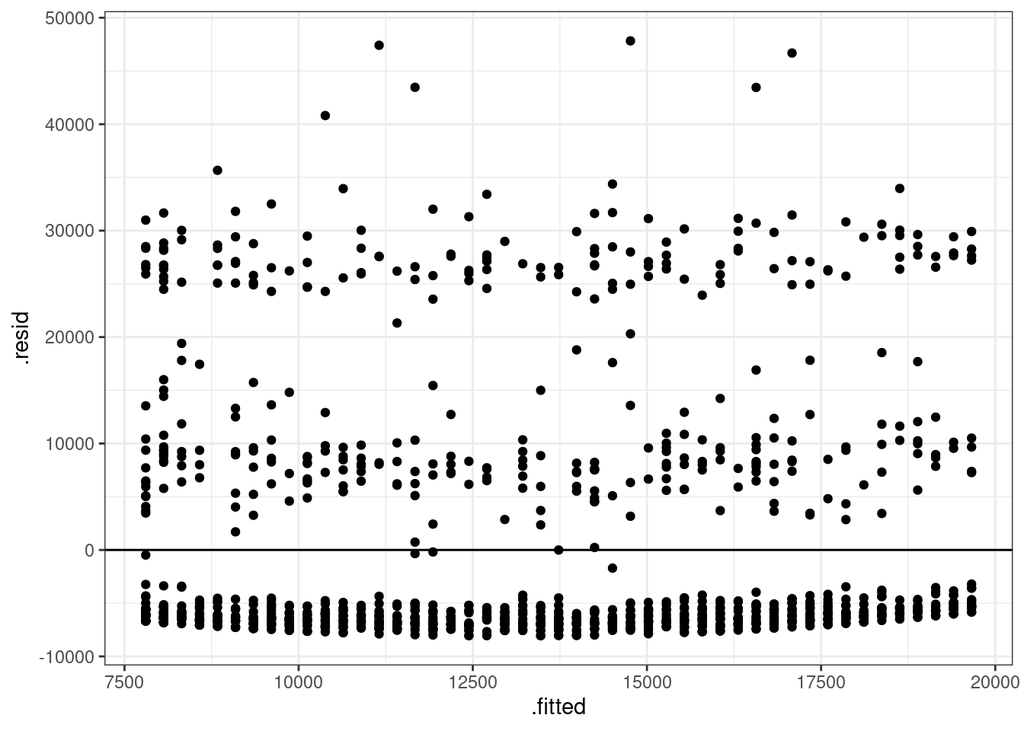

```r
ggplot(model1, aes(x = .fitted, y = .resid)) +
  geom_point() +
  geom_hline(yintercept = 0) + theme_bw()
```

This is clearly (hopefully) not just random scatter.

Next is a plot of the distribution of residuals. We can use a histogram for this. Ideally, this histogram should look like a Normal distribution.

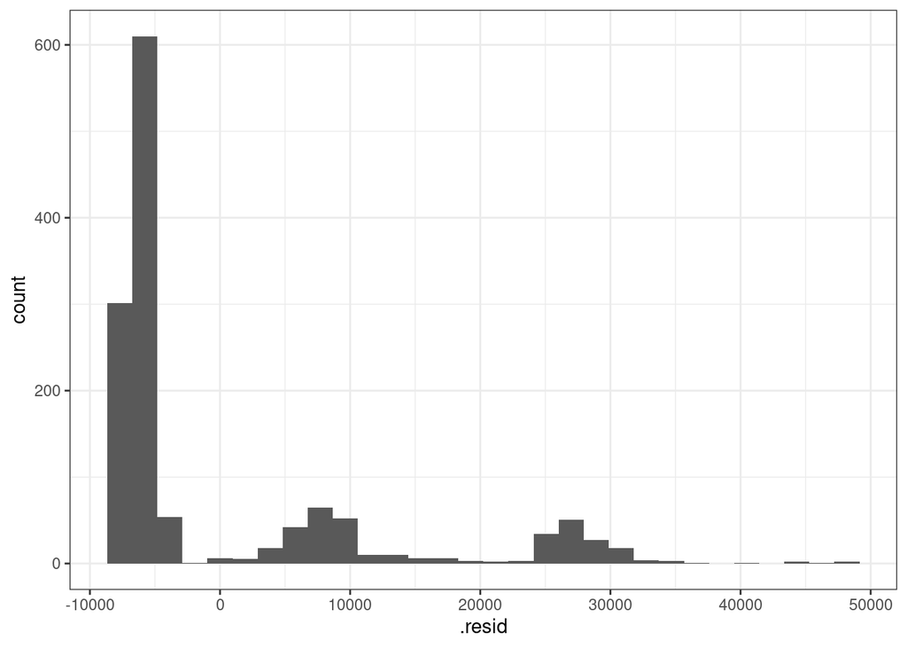

```r
ggplot(model1, aes(x = .resid)) +
  geom_histogram() +
  theme_bw()
```

Clearly (hopefully) not Normal!

Let’s repeat this analysis, but for the smoker variable.  
NOTE: smoker is categorical! This will change our interpretation of results!!

```r
model2 = lm(charges ~ smoker, insurance)
```

```r
summary(model2)
```

```
Call:
lm(formula = charges ~ smoker, data = insurance)

Residuals:
   Min     1Q Median     3Q    Max
-19221  -5042   -919   3705  31720

Coefficients:
            Estimate Std. Error t value Pr(>|t|)
(Intercept)  32050.2      451.3   71.02   <2e-16 ***
smokerno    -23616.0      506.1  -46.66   <2e-16 ***
---
Signif. codes:  0 '***' 0.001 '**' 0.01 '*' 0.05 '.' 0.1 ' ' 1

Residual standard error: 7470 on 1336 degrees of freedom
Multiple R-squared:  0.6198,    Adjusted R-squared:  0.6195
F-statistic:  2178 on 1 and 1336 DF,  p-value: < 2.2e-16
```

Better than our age model, but how do we interpret this? What does “smokerno” mean?

What are the levels of the smoker variable?

R is encoding the levels like this:

smoker = yes –> 0

smoker = no –> 1

So, the regression model looks like this:

charges = 32050 - 23616*smokerno

## If the person is NOT a smoker, we predict charges of 32050 - 23616*1 = 8434

## If they ARE a smoker, the prediction is 32050 - 23616*0 = 32050

It’s pretty clear that smoker is an important variable (we see this from our visualizations and our model with smoker as the predictor). Where do we go from here?

A typical process would be to add one variable at a time, stopping when the model fails to improve or when the improvement is not big enough to justify adding complexity (more variables = more complex). Broadly speaking, such an approach might be called

# **forward selection**.

When you have all numeric variables, forward selection is very straightforward. You would typically add one variable at a time in decreasing order of correlation (from best to worst). It’s a little more complicated when you have categorical variables. We’ll need to use a little bit of judgement.

6 potential variables…

Let’s take the model with just “smoker” and add “age” and see what happens.

```r
model3 = lm(charges ~ smoker + age, insurance)
```

```r
summary(model3)
```

```
Call:
lm(formula = charges ~ smoker + age, data = insurance)

Residuals:
     Min       1Q   Median       3Q      Max
-16088.1  -2046.8  -1336.4   -212.7  28760.0

Coefficients:
             Estimate Std. Error t value Pr(>|t|)
(Intercept)  21463.68     616.00   34.84   <2e-16 ***
smokerno    -23855.30     433.49  -55.03   <2e-16 ***
age            274.87      12.46   22.07   <2e-16 ***
---
Signif. codes:  0 '***' 0.001 '**' 0.01 '*' 0.05 '.' 0.1 ' ' 1

Residual standard error: 6397 on 1335 degrees of freedom
Multiple R-squared:  0.7214,    Adjusted R-squared:  0.721
F-statistic:  1728 on 2 and 1335 DF,  p-value: < 2.2e-16
```

How does this model look? Did the model improve?

### This displays our best Multiple R squared value. But once adding in more (**forward selection**), we will look at the adjusted R squared.

Let’s add bmi.

```r
model4 = lm(charges ~ smoker + age + bmi, insurance)
```

```r
summary(model4)
```

```
Call:
lm(formula = charges ~ smoker + age + bmi, data = insurance)

Residuals:
     Min       1Q   Median       3Q      Max
-12415.4  -2970.9   -980.5   1480.0  28971.8

Coefficients:
             Estimate Std. Error t value Pr(>|t|)
(Intercept)  12146.85     987.09   12.31   <2e-16 ***
smokerno    -23823.68     412.87  -57.70   <2e-16 ***
age            259.55      11.93   21.75   <2e-16 ***
bmi            322.62      27.49   11.74   <2e-16 ***
---
Signif. codes:  0 '***' 0.001 '**' 0.01 '*' 0.05 '.' 0.1 ' ' 1

Residual standard error: 6092 on 1334 degrees of freedom
Multiple R-squared:  0.7475,    Adjusted R-squared:  0.7469
F-statistic:  1316 on 3 and 1334 DF,  p-value: < 2.2e-16
```

How does this model look? Did the model improve?

### Both R squared values went up

```r
model5 = lm(charges ~ smoker + age + bmi + children, insurance)
```

```r
summary(model5)
```

```
Call:
lm(formula = charges ~ smoker + age + bmi + children, data = insurance)

Residuals:
     Min       1Q   Median       3Q      Max
-11897.9  -2920.8   -986.6   1392.2  29509.6

Coefficients:
             Estimate Std. Error t value Pr(>|t|)
(Intercept)  11708.63     991.35  11.811  < 2e-16 ***
smokerno    -23811.40     411.22 -57.904  < 2e-16 ***
age            257.85      11.90  21.675  < 2e-16 ***
bmi            321.85      27.38  11.756  < 2e-16 ***
children       473.50     137.79   3.436 0.000608 ***
---
Signif. codes:  0 '***' 0.001 '**' 0.01 '*' 0.05 '.' 0.1 ' ' 1

Residual standard error: 6068 on 1333 degrees of freedom
Multiple R-squared:  0.7497,    Adjusted R-squared:  0.7489
F-statistic: 998.1 on 4 and 1333 DF,  p-value: < 2.2e-16
```

How does this model look? Did the model improve?

### Both R squared values are good

```r
model6 = lm(charges ~ smoker + age + bmi + children + sex, insurance)
```

```r
summary(model6)
```

```
Call:
lm(formula = charges ~ smoker + age + bmi + children + sex, data = insurance)

Residuals:
     Min       1Q   Median       3Q      Max
-11837.2  -2916.7   -994.2   1375.3  29565.5

Coefficients:
             Estimate Std. Error t value Pr(>|t|)
(Intercept)  11770.93    1004.72  11.716  < 2e-16 ***
smokerno    -23823.39     412.52 -57.750  < 2e-16 ***
age            257.73      11.90  21.651  < 2e-16 ***
bmi            322.36      27.42  11.757  < 2e-16 ***
children       474.41     137.86   3.441 0.000597 ***
sexmale       -128.64     333.36  -0.386 0.699641
---
Signif. codes:  0 '***' 0.001 '**' 0.01 '*' 0.05 '.' 0.1 ' ' 1

Residual standard error: 6070 on 1332 degrees of freedom
Multiple R-squared:  0.7497,    Adjusted R-squared:  0.7488
F-statistic:   798 on 5 and 1332 DF,  p-value: < 2.2e-16
```

### The adjusted R squared value dips down

OK. So the sex variable is NOT significant! We have a few options:

1. We can stop. We would perform diagnostics on Model 5 and it would be our best candidate as the “champion” model.
2. We can try the region variable in place of sex. This is worth doing.

```r
model7 = lm(charges ~ smoker + age + bmi + children + region, insurance)
```

```r
summary(model7)
```

```
Call:
lm(formula = charges ~ smoker + age + bmi + children + region,
    data = insurance)

Residuals:
     Min       1Q   Median       3Q      Max
-11367.2  -2835.4   -979.7   1361.9  29935.5

Coefficients:
                 Estimate Std. Error t value Pr(>|t|)
(Intercept)      10886.66    1057.51  10.295  < 2e-16 ***
smokerno        -23836.30     411.86 -57.875  < 2e-16 ***
age                256.97      11.89  21.610  < 2e-16 ***
bmi                338.66      28.56  11.858  < 2e-16 ***
children           474.57     137.74   3.445 0.000588 ***
regionsoutheast    -74.99     470.49  -0.159 0.873396
regionnorthwest    607.19     477.05   1.273 0.203311
regionnortheast    959.37     477.78   2.008 0.044846 *
---
Signif. codes:  0 '***' 0.001 '**' 0.01 '*' 0.05 '.' 0.1 ' ' 1

Residual standard error: 6060 on 1330 degrees of freedom
Multiple R-squared:  0.7509,    Adjusted R-squared:  0.7496
F-statistic: 572.7 on 7 and 1330 DF,  p-value: < 2.2e-16
```

### Eh, it kinda moved in the adjusted R squared value

This is a tough call. Let’s talk about the region variable for a moment.

charges = 10887 -23836*smoker + 257*age + 339*bmi + 475*children - 75*SE + 607*NW + 959*NE

### if one category is significant, it is significant

### location is importnant

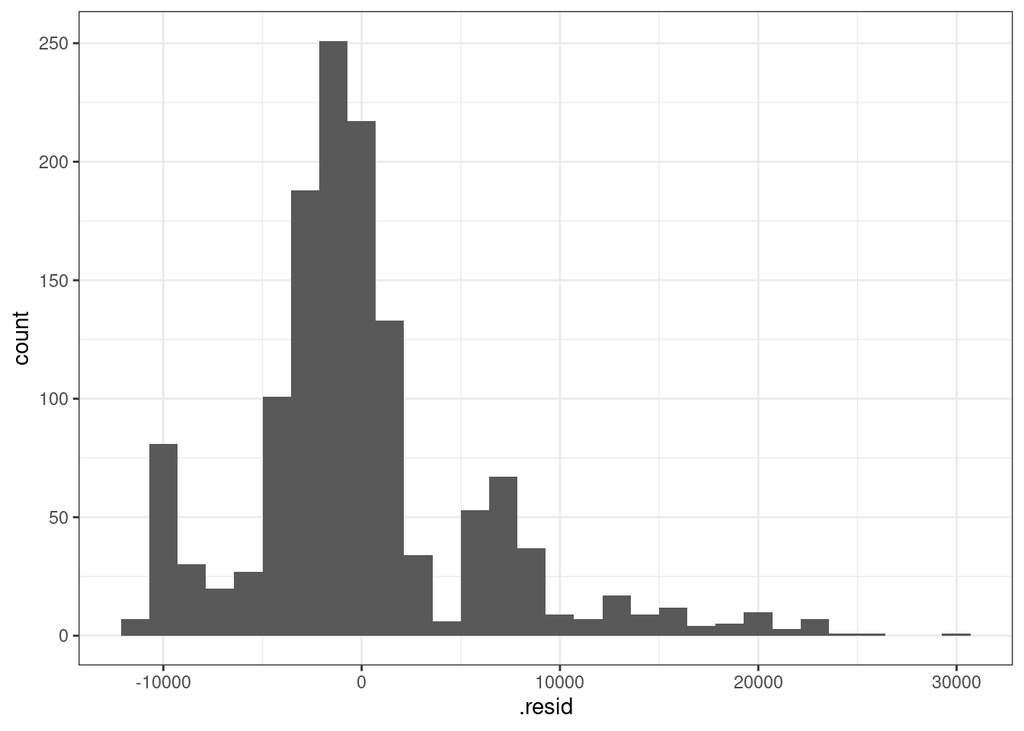

```r
ggplot(model6, aes(x=.resid)) + geom_histogram() + theme_bw()
```

Residuals aren’t terrible looking, but appear to be somewhat skewed.

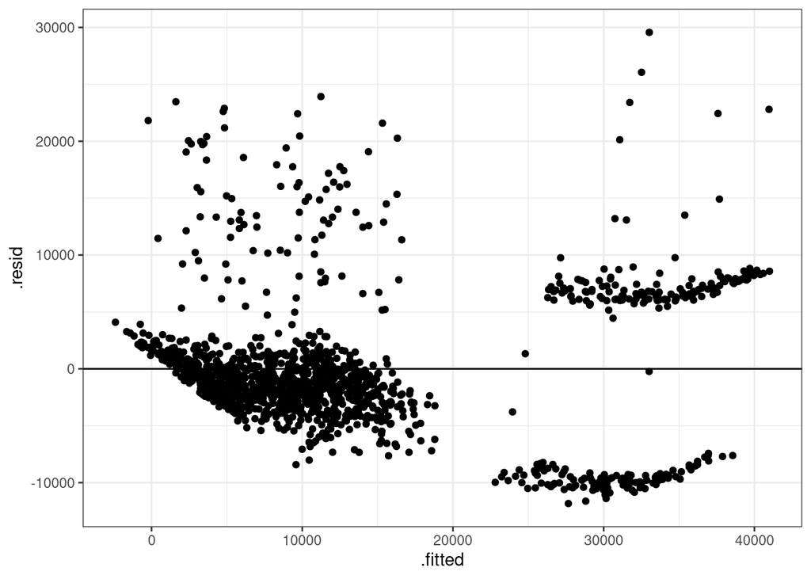

```r
ggplot(model6, aes(x=.fitted,y=.resid)) + geom_point() +
  geom_hline(yintercept = 0) + theme_bw()
```

This is clearly NOT random scatter. Unfortunately, there’s probably not much that we can do about it in this case.